# COD_3

Dominic Felice

## Front Matter

```r
remove(list = ls())
#Load Libraries
library(tidyverse)
library(readxl)
library(lubridate)
library(glmnet)
library(rpart)
library(rattle)
Games <- read_excel("Datasets/CODGames2_mp.xlsx")
```

### Task 1

#### Filtering Partial Cases

```r
Games2 <-
  Games %>%
  filter(FullPartial == "Full")
Games2
```

```
## # A tibble: 191 × 27
##    Map1              Map2  Choice MapVote Date                FullPartial Result
##    <chr>             <chr> <chr>  <chr>   <dttm>              <chr>       <chr>
##  1 Moscow            Miam… Miami… 5 to 0  2022-06-06 00:00:00 Full        100-97
##  2 Moscow            WMD   Moscow 2 to 0  2022-06-06 00:00:00 Full        76-89
##  3 <NA>              <NA>  Yaman… <NA>    2022-06-06 00:00:00 Full        100-92
##  4 Drive-In          Jung… Drive… 2 to 0  2022-06-06 00:00:00 Full        80-100
##  5 Collateral Strike Hija… Colla… 3 to 3  2022-06-06 00:00:00 Full        71-100
##  6 Crossroads Strike Raid  Raid   4 to 3  2022-06-06 00:00:00 Full        85-100
##  7 <NA>              <NA>  WMD    <NA>    2022-06-06 00:00:00 Full        86-100
##  8 The Pines         Stan… Stand… 5 to 1  2022-06-06 00:00:00 Full        100-70
##  9 Echelon           Depr… Depro… 1 to 0  2022-06-12 00:00:00 Full        46-65
## 10 Nuketown '84      Hija… Nuket… 1 to 1  2022-06-12 00:00:00 Full        47-65
## # ℹ 181 more rows
## # ℹ 20 more variables: Eliminations <dbl>, Deaths <dbl>, Score <dbl>,
## #   Damage <dbl>, TotalXP <dbl>, PrimaryWeapon <chr>, XPType <chr>,
## #   DidPlayerVote <chr>, GameType <chr>, Confirms <dbl>, Denies <dbl>,
## #   Objectives <dbl>, ObjectiveKills <dbl>, Captures <dbl>, Diffuses <lgl>,
## #   Plants <lgl>, Detonates <lgl>, Deposits <lgl>, Time_Sec <dbl>,
## #   Time_Min <dbl>
```

#### Side-By-Side Boxplots

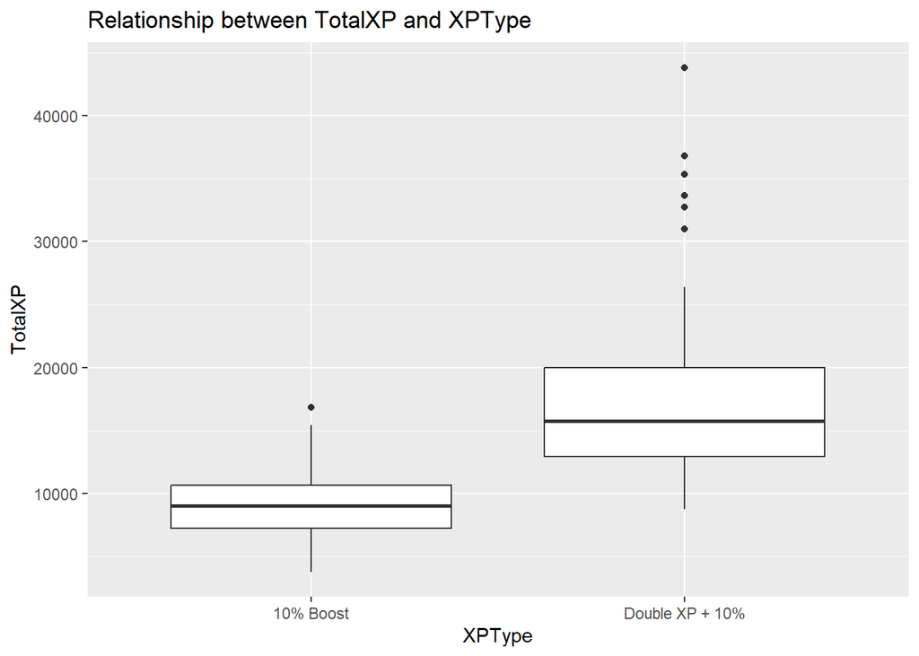

```r
ggplot(Games2, aes(x = XPType, y = TotalXP)) +
  geom_boxplot() +
  labs(title = "Relationship between TotalXP and XPType",
       x = "XPType",
       y = "TotalXP")
```

#### Summary Statistics

```r
tapply(Games2$TotalXP, Games2$XPType, summary)
```

```
## $`10% Boost`
##    Min. 1st Qu.  Median    Mean 3rd Qu.    Max.
##    3795    7216    9039    9094   10650   16831
##
## $`Double XP + 10%`
##    Min. 1st Qu.  Median    Mean 3rd Qu.    Max.
##    8772   12909   15738   17242   19985   43816
```

I have learned that the relationship between TotalXP and XPType is in favor of “Double XP + 10%” XP type as it consistently results in higher TotalXP compared to the “10% Boost” XP type across all quartiles and the mean. For “Double XP + 10%”, the minimum, 1st quartile, median, mean, 3rd quartile, and maximum TotalXP values are all greater than those of “10% Boost”. This indicates that opting for “Double XP + 10%” offers a more substantial boost in XP accumulation than simply utilizing the “10% Boost” option. Therefore, players seeking to maximize their XP gains would likely benefit more from choosing the “Double XP + 10%” option over the “10% Boost” alternative.